# Final_Project_Code

Author

Elliot Kunz, Andrea Pareja, Anson Wu, Caroline Ritchey

Published

June 6, 2025

```r
library(tidyverse)
library(knitr)
library(kableExtra)
library(broom)
library(gganimate)
library(gifski)
```

## Introduction

In this analysis, we use data collected by Gallup World Poll on November 20, 2024 which contains the national average response to the question of life evaluations. We additionally include information from a data set provided by Gapminder on the mean daily household per capital income. Our analysis includes the years 2005 - 2023. We omitted any countries and years who had missing values for either the happiness score or their mean daily household per capital income. We believe that as daily income increases, so does the happiness score (WHR). Typically higher incomes means more financial freedom, this lowers the stress that is built up from worrying about financial problems like cost of living. In the article, “Does more money correlate with greater happiness?” by Michele W. Berger, Matthew Killingsworth argues that “for most people larger incomes are associated with greater happiness” (Berger 2023).

## Data Cleaning

We transformed both files so they could be joined by year and country which would give us a final data set that contains the Happiness Score and Daily Income for each country and year combination. We also removed any missing values from the data so that the data points were not skewed. The Happiness Score data only had information on the years 2005 to 2023 while the data on Daily Income had information from 1800 to 2100 for each country. The values for daily income past 2024 are all predictions based on the countries daily income. Thus we decided to just use the years between 2005 and 2023 which had actual information, not predicted, for both daily income and happiness score. Below shows a sample of the data we used moving forward.

```r
data1 <- read_csv("hapiscore_whr.csv", show_col_types = F)
data2 <- read_csv("mincpcap_cppp.csv", show_col_types = F)

clean_data1 <- data1 %>%
  pivot_longer(cols = `2005`:`2023`,
              names_to = "year",
              values_to = "happiness")

clean_data2 <- data2 %>%
  pivot_longer(cols = `1800`:`2100`,
              names_to = 'year',
              values_to = "daily_income")

data <- clean_data1 %>%
  inner_join(clean_data2,
             by = join_by(country == country, year == year)) %>%
  na.omit()

kable(sample_n(data, size = 10), col.names = c("Country", "Year", "Happiness"," Daily Income"), align = "c", digits = 2)
```

| Country | Year | Happiness | Daily Income |
| --- | --- | --- | --- |
| Pakistan | 2015 | 48.2 | 5.12 |
| Philippines | 2013 | 49.8 | 7.21 |
| Kuwait | 2022 | 67.6 | 50.10 |
| Ecuador | 2010 | 58.4 | 13.40 |
| Turkmenistan | 2013 | 53.9 | 9.43 |
| Senegal | 2018 | 47.7 | 5.98 |
| Kuwait | 2009 | 65.8 | 66.10 |
| Denmark | 2013 | 75.9 | 58.70 |
| Slovenia | 2014 | 56.8 | 37.80 |
| Slovak Republic | 2006 | 52.6 | 18.80 |

## Modeling the Relationship between Happiness and Daily Income

The next step in our process was to view the relationship between Happiness Score and Daily Income. Each dot on the scatter plot below represents a Country with their mean Happiness Score and mean Daily Income from 2005 to 2023.

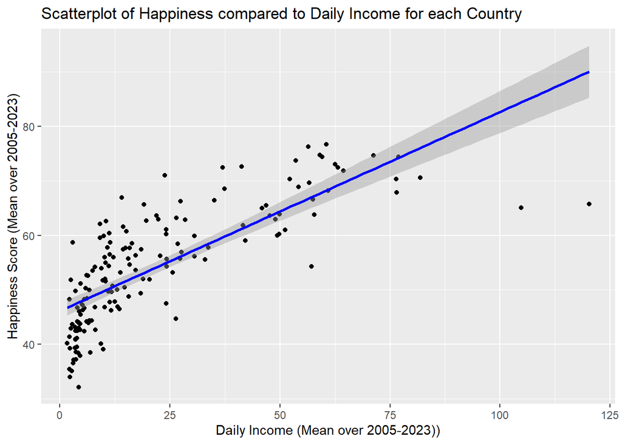

```r
grouped_data <- data %>%
  group_by(country) %>%
  summarise(happiness = mean(happiness),
            daily_income = mean(daily_income))


ggplot(data = grouped_data, mapping = aes(x = daily_income, y = happiness))+
  geom_point()+
  geom_smooth(colour = "blue", method = "lm")+
  labs(x = "Daily Income (Mean over 2005-2023))",
       y = "Happiness Score (Mean over 2005-2023)",
       title = "Scatterplot of Happiness compared to Daily Income for each Country")
```

As you can see in the data the when we try to fit a linear line through the data it does not fit well. Thus we decided to transform the data which after testing, we decided to transform the mean Daily Income for each country using a natural logarithmic transformation. Below is the scatter plot and linear fit of this transformed data.

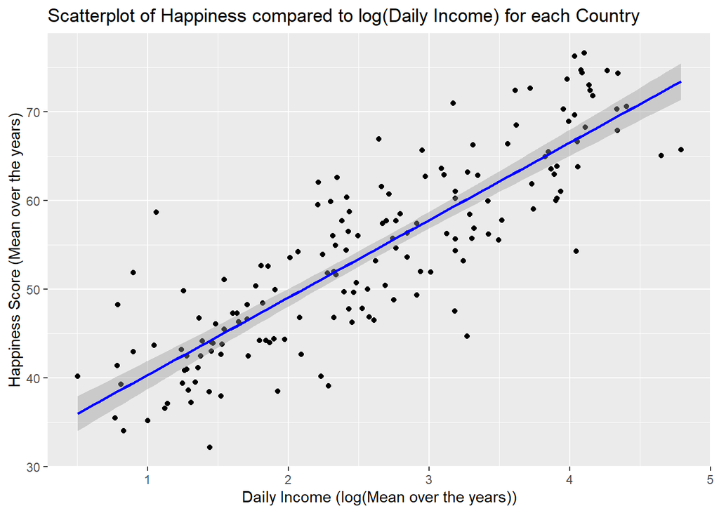

```r
ggplot(data = grouped_data, mapping = aes(x = log(daily_income), y = happiness))+
  geom_point()+
  geom_smooth(colour = "blue", method = lm)+
  labs(x = "Daily Income (log(Mean over the years))",
       y = "Happiness Score (Mean over the years)",
       title = "Scatterplot of Happiness compared to log(Daily Income) for each Country")
```

Here we can see that the trend of happiness increasing as daily income also increases in a strong positive linear relationship. Thus we can infer that as Daily Income increases we expect an increase in the Happiness Score of a country. However, the above plots only shows the mean over time for each of these countries. We also want to check if this relationship is seen every year of the data and not just on the overall means. Thus we decided to look at the changes in the relationship over time. The plot below shows each countries happiness score compared to daily income for each year between 2005 and 2023.

```r
#|eval: false

animated_plot <- ggplot(data = data, mapping = aes(x = log(daily_income), y = happiness)) +
  geom_point() +
  geom_smooth(method = "lm", se = FALSE, color = "blue", alpha = 0.5) +
  transition_states(
    year,
    transition_length = 2,
    state_length = 1
  ) +
  enter_fade() +
  exit_shrink() +
  ease_aes('sine-in-out') +
  labs(
    x = "log(Daily Income)",
    y = "Happiness Score",
    title = "Happiness vs Daily Income by Country",
    subtitle = "Year: {closest_state}") +
  theme_minimal()

animate(animated_plot,
        width = 800,
        height = 600,
        fps = 10,
        renderer = gifski_renderer("happiness_animation.gif"))
```

[output not shown]

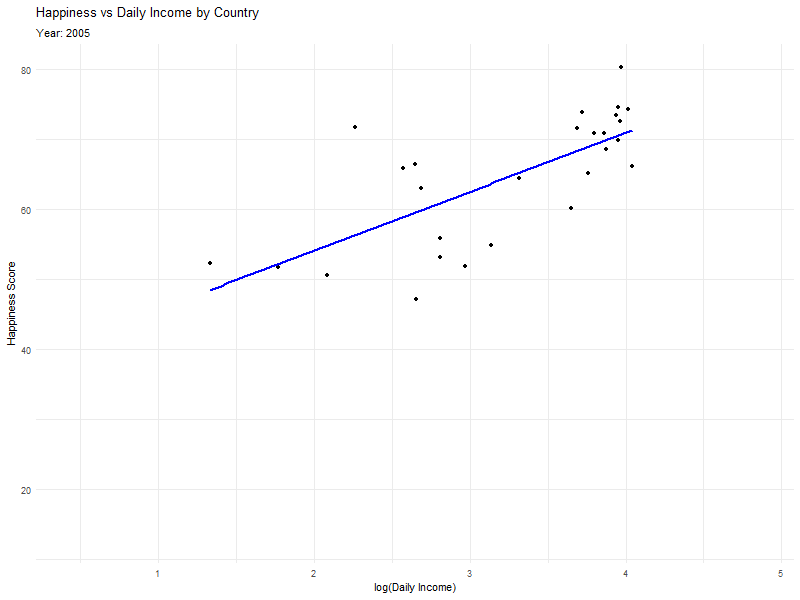

Based on the animated plot the line over time stays relatively the same with some years having a stronger relationship than other years. We still see a positive relationship in all years between the the mean daily income and happiness score which indicates that the mean daily income for each country could be a strong predictor of the happiness score for the country.

```r
model <- lm(happiness ~ log(daily_income), data = grouped_data)
```

We also made a linear model to predict the mean Happiness Score based on the log of the mean Daily Income for each country. This will give us a more accurate understanding of the strength of the relationship between Happiness Score and Daily Income.

```r
tidy(model$coefficients) %>%
  kable(col.names = c("Predictor Names", "Regression Coefficients"), align = 'c', digits = 2) %>%
  kableExtra::kable_classic() %>%
  row_spec(0, bold = TRUE) %>%
  add_header_above(bold = TRUE, c("Table of Coefficients for Fitted Model" = 2))
```

| Table of Coefficients for Fitted Model Predictor Names | Table of Coefficients for Fitted Model Regression Coefficients |
| --- | --- |
| (Intercept) | 31.59 |
| log(daily_income) | 8.73 |

Based on the table above the regression equation is:

${\hat{HappinessScore}} = 31.59 + 8.73*log(DailyIncome)$

From this model we predict that a country with a log of their mean daily income equal to 0 will have a mean happiness score of 31.59 over the years 2005 to 2023. If we multiply the mean Daily Income by e (approximately 2.718), we predict a increase of 8.73 in the mean Happiness Score for a country. This is a significant increase in the Happiness score since the value is a score between 1 and 100. Thus, we predict that whenever Daily Income increases we should see an increase in the Happiness score for a country. Below is a table showing the variance of our model which is helpful for analysis of the overall performance of our model.

```r
aug_data <- model %>%
  augment()

data.frame(
  Var_Response_A = var(aug_data$happiness),
  Var_Fitted_B = var(aug_data$.fitted),
  Var_Residuals = var(aug_data$.resid),
  R_Squared = summary(model)$r.squared
) %>%
  kable(align = "c") %>%
  kableExtra::kable_classic() %>%
  row_spec(0, bold = TRUE) %>%
  add_header_above(bold = TRUE, c("Model Variance Table" = 4)) %>%
  kable_styling(full_width = TRUE, bootstrap_options = c("striped", "bordered"))
```

| Model Variance Table Var_Response_A | Model Variance Table Var_Fitted_B | Model Variance Table Var_Residuals | Model Variance Table R_Squared |
| --- | --- | --- | --- |
| 113.5732 | 82.0968 | 31.4764 | 0.7228536 |

```r
# https://broom.tidymodels.org/reference/augment.lm.html
```

The total variance in Happiness Score is 113.57. 82.10 of this is accounted for by the regression model based on the log of the mean daily income. The other 31.48 is unexplained. For this model, the R squared value of 0.7228 means that 72.28% of the variability in happiness can be explained by the log of daily income. The value comes from dividing the variance in Happiness Score explained by the model by the total variance in Happiness Score. This is a rather high percent and suggests that this is a well fit model that is able to identify the main trend in this data.

## Cross-Validation

```r
process_folds <- function(index) {
    train_data <- data[-index, ]
    val_data <- data[index, ]
    model <- lm(happiness ~ daily_income, data = train_data)
    predict <- predict(model, newdata = val_data)
    r2 <- (var(predict) / var(val_data[["happiness"]]))
    return(r2)
  }

kfold_cv <- function(data, k = 16, seed = 23) {
  set.seed(seed)
  n <- nrow(data)
  fold_ids <- sample(rep_len(1:k, length.out = n))
  folds <- map(1:k, ~ which(fold_ids == .x))
  r2_values <- map_dbl(folds, process_folds)
  results <- data.frame(fold = 1:k, R2 = r2_values)
  return(results)
}

k_fold <- kfold_cv(grouped_data)
k_fold %>%
  kable(col.names = c("Fold", "R-Squared Value"), align = 'c', digits = 4) %>%
  kableExtra::kable_classic() %>%
  row_spec(0, bold = TRUE) %>%
  add_header_above(bold = TRUE, c("R-Squared Value for each Fold" = 2))
```

| R-Squared Value for each Fold Fold | R-Squared Value for each Fold R-Squared Value |
| --- | --- |
| 1 | 0.5024 |
| 2 | 0.7128 |
| 3 | 1.0604 |
| 4 | 0.6035 |
| 5 | 0.7141 |
| 6 | 0.2119 |
| 7 | 0.4385 |
| 8 | 0.7212 |
| 9 | 0.3845 |
| 10 | 0.1872 |
| 11 | 0.8181 |
| 12 | 0.4153 |
| 13 | 0.3196 |
| 14 | 1.0337 |
| 15 | 0.3535 |
| 16 | 0.5301 |

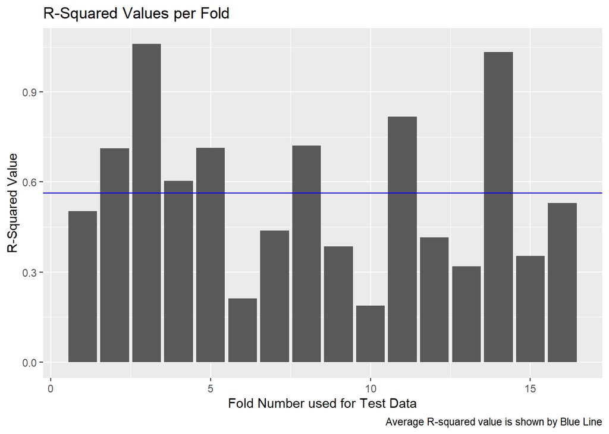

```r
ggplot(data = k_fold)+
  geom_col(mapping = aes(x = fold, y = R2))+
  geom_hline(yintercept = mean(k_fold$R2), color = "blue") +
  labs(title = "R-Squared Values per Fold",
       x = "Fold Number used for Test Data",
       y = "R-Squared Value",
       caption = "Average R-squared value is shown by Blue Line")
```

## Conclusion

The analysis of the positive relationship between daily income and happiness scores in various countries corroborates theories about the way money can help alleviate stressors caused by lack of finances. The increase of money can be used to access housing, better healthcare, more fulfilling experiences, and much more. Although we found that higher daily incomes are associated with higher happiness scores, happiness can be influenced by other things that are not gathered by daily income like personal values and religion.

Our model does have limitations. We can see that there is a positive relationship between daily income and happiness scores. However, it is important to acknowledge that there can be a point where money can have diminishing returns in terms of happiness. Infinite money would not necessarily mean infinite happiness. So, although money cannot buy happiness, money seems to be a basis where it can expand the opportunities to increase happiness.

## Works Cited

Berger, Michele W. “Does More Money Correlate with Greater Happiness?” Penn Today, University of Pennsylvania, 6 Mar. 2023, penntoday.upenn.edu/news/does-more-money-correlate-greater-happiness-Penn-Princeton-research.

Helliwell, John F., et al. “World Happiness Report 2024.” The World Happiness Report, 20 Mar. 2024, worldhappiness.report/ed/2024/.

“Poverty and Inequality Platform.” Poverty and Inequality Platform, 2022, pip.worldbank.org/#.

GitHub Repository: https://github.com/edkunz/STAT331-Final_Projet